# Classification Task - Gym data

Julian Cuero

27/12/2020

## Loading packages

```r
library(caret)
library(randomForest)
```

```r
library(lubridate)
library(ggplot2)
library(gridExtra)
```

## Intro

One thing that people regularly do is quantify how much of a particular activity they do, but they rarely quantify how well they do it. In this project, data from accelerometers on the belt, forearm, arm, and dumbell of 6 participants is used to quantify how well they work out.

## Getting the data

```r
training <- read.csv('pml-training.csv')
testing <- read.csv('pml-testing.csv')
```

## Performing some data cleaning

In order to quantify how well the subjects work out the outcome variable `classe` was used for this purpose.

```r
table(training$classe)
```

```
##
##    A    B    C    D    E
## 5580 3797 3422 3216 3607
```

Since there are just 5 levels, it is converted to factor because it was originally stored as character. Something similar is done for the `new_window` variable and the timestamp is converted to date.

```r
training2 <- within(training, {
    classe <- as.factor(classe)
    new_window <- as.factor(new_window)
    cvtd_timestamp <- dmy_hm(cvtd_timestamp)
})
```

It’s necessary to apply what was done in the training set to the test set. However it’s not performed in the outcome variable because it is not present.

```r
testing2 <- within(testing, {
    new_window <- as.factor(new_window)
    cvtd_timestamp <- dmy_hm(cvtd_timestamp)
})
```

The `X` and `user_name` variables are removed since they just serve as a subject identifier.

```r
training2 <- subset(training2, select=-c(X, user_name))
testing2 <- subset(testing2, select=-c(X, user_name, problem_id))
```

**Convert character to numeric** - If character or logical convert to numeric because the rest of character/logical variables in the training and test sets contain numeric values.

```r
to_numeric <- function(df){
    for(col in names(df)){
        col_type <- class(df[,c(col)])[1]

        if(col_type == "character" | col_type == "logical"){
            df[,c(col)] <- as.numeric(df[,c(col)])
        }
    }

    df
}
```

```r
training2 <- to_numeric(training2)
testing2 <- to_numeric(testing2)
```

```r
clean_dat <- function(df){
    exclude_cols <- character()
    total_rows <- nrow(df)

    for(col in names(df)){

        # Count # of NAs for a particular col
        total_nas <- sum(is.na(df[,c(col)]))
        na_proportion <- total_nas / total_rows

        # Check if it reaches the threshold
        if (total_nas > .97){
            exclude_cols <- append(exclude_cols, col)
        }
    }

    exclude_cols

}
```

```r
exclude_cols <- clean_dat(training2)
```

Remove cols from both training and test sets.

```r
training_clean <- training2[, !(names(training2) %in% exclude_cols)]
testing_final <- testing2[, !(names(testing2) %in% exclude_cols)]
```

## Modeling

Since there are 5 labels for the outcome variable and there are more than 50 features, a simple random forest model is trained.

### Create validation set

```r
set.seed(9265)
inBuild <- createDataPartition(y=training_clean$classe,
                               p=.75, list=FALSE)

training_final <- training_clean[inBuild,]
validation_final <- training_clean[-inBuild,]
```

It’s important to note that 3 candidate models are trained in order to choose the final one based on its accuracy. Each of those try to predict `classe` using all the other variables.

### 1. Create simple random forest

```r
set.seed(4250)
simple_rf <- randomForest(classe ~ ., data=training_final,
                          importance=TRUE)
```

#### Measure accuracy

```r
pred_simple_rf <- predict(simple_rf, validation_final[,-58])
```

Simple random forest accuracy: **0.9994**

```r
xtab <- table(pred_simple_rf, validation_final$classe)
confusionMatrix(xtab)
```

```
## Confusion Matrix and Statistics
##
##
## pred_simple_rf    A    B    C    D    E
##              A 1395    0    0    0    0
##              B    0  949    2    0    0
##              C    0    0  853    0    0
##              D    0    0    0  804    1
##              E    0    0    0    0  900
##
## Overall Statistics
##
##                Accuracy : 0.9994
##                  95% CI : (0.9982, 0.9999)
##     No Information Rate : 0.2845
##     P-Value [Acc > NIR] : < 2.2e-16
##
##                   Kappa : 0.9992
##
##  Mcnemar's Test P-Value : NA
##
## Statistics by Class:
##
##                      Class: A Class: B Class: C Class: D Class: E
## Sensitivity            1.0000   1.0000   0.9977   1.0000   0.9989
## Specificity            1.0000   0.9995   1.0000   0.9998   1.0000
## Pos Pred Value         1.0000   0.9979   1.0000   0.9988   1.0000
## Neg Pred Value         1.0000   1.0000   0.9995   1.0000   0.9998
## Prevalence             0.2845   0.1935   0.1743   0.1639   0.1837
## Detection Rate         0.2845   0.1935   0.1739   0.1639   0.1835
## Detection Prevalence   0.2845   0.1939   0.1739   0.1642   0.1835
## Balanced Accuracy      1.0000   0.9997   0.9988   0.9999   0.9994
```

### 2. Create Principal Component Analysis (PCA) random forest

```r
preProc <- preProcess(training_final[,-58], method = "pca",
                      pcaComp = 3)
trainPC <- predict(preProc, training_final[,-58])
pca_rf <- randomForest(training_final$classe ~ ., data=trainPC,
                       importance=TRUE)

valPC <- predict(preProc, validation_final[,-58])
```

#### Measure accuracy

```r
pred_pca_rf <- predict(pca_rf, valPC)
xtab2 <- table(pred_pca_rf, validation_final$classe)
```

PCA random forest accuracy: **0.84**

```r
confusionMatrix(xtab2)
```

```
## Confusion Matrix and Statistics
##
##
## pred_pca_rf    A    B    C    D    E
##           A 1268  112   19    0    0
##           B   74  707   70   16    0
##           C   52  121  709   73   16
##           D    1    9   53  644  101
##           E    0    0    4   71  784
##
## Overall Statistics
##
##                Accuracy : 0.8385
##                  95% CI : (0.8279, 0.8487)
##     No Information Rate : 0.2845
##     P-Value [Acc > NIR] : < 2.2e-16
##
##                   Kappa : 0.7958
##
##  Mcnemar's Test P-Value : NA
##
## Statistics by Class:
##
##                      Class: A Class: B Class: C Class: D Class: E
## Sensitivity            0.9090   0.7450   0.8292   0.8010   0.8701
## Specificity            0.9627   0.9595   0.9353   0.9600   0.9813
## Pos Pred Value         0.9064   0.8155   0.7302   0.7970   0.9127
## Neg Pred Value         0.9638   0.9401   0.9629   0.9609   0.9711
## Prevalence             0.2845   0.1935   0.1743   0.1639   0.1837
## Detection Rate         0.2586   0.1442   0.1446   0.1313   0.1599
## Detection Prevalence   0.2853   0.1768   0.1980   0.1648   0.1752
## Balanced Accuracy      0.9358   0.8523   0.8823   0.8805   0.9257
```

#### 3. Merge the two previous models

```r
predDF <- data.frame(pred_simple_rf, pred_pca_rf, classe=validation_final$classe)
```

```r
combRf <- randomForest(classe ~ ., data=predDF,
                       importance=TRUE)
```

#### Measure accuracy

```r
combPred <- predict(combRf, predDF)
xtab3 <- table(combPred, validation_final$classe)
```

Merged random forest accuracy: **0.9994**

```r
confusionMatrix(xtab3)
```

```
## Confusion Matrix and Statistics
##
##
## combPred    A    B    C    D    E
##        A 1395    0    0    0    0
##        B    0  949    2    0    0
##        C    0    0  853    0    0
##        D    0    0    0  804    1
##        E    0    0    0    0  900
##
## Overall Statistics
##
##                Accuracy : 0.9994
##                  95% CI : (0.9982, 0.9999)
##     No Information Rate : 0.2845
##     P-Value [Acc > NIR] : < 2.2e-16
##
##                   Kappa : 0.9992
##
##  Mcnemar's Test P-Value : NA
##
## Statistics by Class:
##
##                      Class: A Class: B Class: C Class: D Class: E
## Sensitivity            1.0000   1.0000   0.9977   1.0000   0.9989
## Specificity            1.0000   0.9995   1.0000   0.9998   1.0000
## Pos Pred Value         1.0000   0.9979   1.0000   0.9988   1.0000
## Neg Pred Value         1.0000   1.0000   0.9995   1.0000   0.9998
## Prevalence             0.2845   0.1935   0.1743   0.1639   0.1837
## Detection Rate         0.2845   0.1935   0.1739   0.1639   0.1835
## Detection Prevalence   0.2845   0.1939   0.1739   0.1642   0.1835
## Balanced Accuracy      1.0000   0.9997   0.9988   0.9999   0.9994
```

### Which model was the most accurate on the validation set?

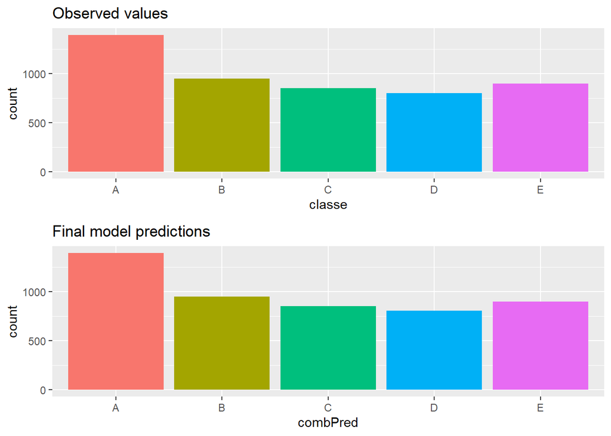

```r
quick_df <- data.frame(combPred=combPred)

p1 <- ggplot(quick_df, aes(combPred, fill=combPred)) + geom_bar() +
    ggtitle("Final model predictions") + theme(legend.position = "none")

p2 <- ggplot(validation_final, aes(classe, fill=classe)) + geom_bar() +
    ggtitle("Observed values") + theme(legend.position = "none")

grid.arrange(p2, p1)
```

##### Sources

http://web.archive.org/web/20161224072740/http:/groupware.les.inf.puc-rio.br/har